# Part I - (Loan Data from Prosper)

## by (Zaburi Frolian Mwachusi)

## Preliminary Wrangling

```python
# import all packages and set plots to be embedded inline
import numpy as np
import pandas as pd
import matplotlib.pyplot as plt
import seaborn as sb
import warnings
warnings.filterwarnings('ignore')

%matplotlib inline
```

```python
#load the dataset
df = pd.read_csv("C:/Users/( ^_^ )/OneDrive/Desktop/Udacity projects/Project 3/prosperLoanData.csv")
```

```python
# high-level overview of data shape and composition
print(df.shape)
print(df.dtypes)
df.head(10)
```

```
(113937, 81)
ListingKey                      object
ListingNumber                    int64
ListingCreationDate             object
CreditGrade                     object
Term                             int64
                                ...
PercentFunded                  float64
Recommendations                  int64
InvestmentFromFriendsCount       int64
InvestmentFromFriendsAmount    float64
Investors                        int64
Length: 81, dtype: object
```

|  | ListingKey | ListingNumber | ListingCreationDate | CreditGrade | Term | LoanStatus | ClosedDate | BorrowerAPR | BorrowerRate | LenderYield | ... | LP_ServiceFees | LP_CollectionFees | LP_GrossPrincipalLoss | LP_NetPrincipalLoss | LP_NonPrincipalRecoverypayments | PercentFunded | Recommendations | InvestmentFromFriendsCount | InvestmentFromFriendsAmount | Investors |
| --- | --- | --- | --- | --- | --- | --- | --- | --- | --- | --- | --- | --- | --- | --- | --- | --- | --- | --- | --- | --- | --- |
| 0 | 1021339766868145413AB3B | 193129 | 2007-08-26 19:09:29.263000000 | C | 36 | Completed | 2009-08-14 00:00:00 | 0.16516 | 0.1580 | 0.1380 | ... | -133.18 | 0.0 | 0.0 | 0.0 | 0.0 | 1.0 | 0 | 0 | 0.0 | 258 |
| 1 | 10273602499503308B223C1 | 1209647 | 2014-02-27 08:28:07.900000000 | NaN | 36 | Current | NaN | 0.12016 | 0.0920 | 0.0820 | ... | 0.00 | 0.0 | 0.0 | 0.0 | 0.0 | 1.0 | 0 | 0 | 0.0 | 1 |
| 2 | 0EE9337825851032864889A | 81716 | 2007-01-05 15:00:47.090000000 | HR | 36 | Completed | 2009-12-17 00:00:00 | 0.28269 | 0.2750 | 0.2400 | ... | -24.20 | 0.0 | 0.0 | 0.0 | 0.0 | 1.0 | 0 | 0 | 0.0 | 41 |
| 3 | 0EF5356002482715299901A | 658116 | 2012-10-22 11:02:35.010000000 | NaN | 36 | Current | NaN | 0.12528 | 0.0974 | 0.0874 | ... | -108.01 | 0.0 | 0.0 | 0.0 | 0.0 | 1.0 | 0 | 0 | 0.0 | 158 |
| 4 | 0F023589499656230C5E3E2 | 909464 | 2013-09-14 18:38:39.097000000 | NaN | 36 | Current | NaN | 0.24614 | 0.2085 | 0.1985 | ... | -60.27 | 0.0 | 0.0 | 0.0 | 0.0 | 1.0 | 0 | 0 | 0.0 | 20 |
| 5 | 0F05359734824199381F61D | 1074836 | 2013-12-14 08:26:37.093000000 | NaN | 60 | Current | NaN | 0.15425 | 0.1314 | 0.1214 | ... | -25.33 | 0.0 | 0.0 | 0.0 | 0.0 | 1.0 | 0 | 0 | 0.0 | 1 |
| 6 | 0F0A3576754255009D63151 | 750899 | 2013-04-12 09:52:56.147000000 | NaN | 36 | Current | NaN | 0.31032 | 0.2712 | 0.2612 | ... | -22.95 | 0.0 | 0.0 | 0.0 | 0.0 | 1.0 | 0 | 0 | 0.0 | 1 |
| 7 | 0F1035772717087366F9EA7 | 768193 | 2013-05-05 06:49:27.493000000 | NaN | 36 | Current | NaN | 0.23939 | 0.2019 | 0.1919 | ... | -69.21 | 0.0 | 0.0 | 0.0 | 0.0 | 1.0 | 0 | 0 | 0.0 | 1 |
| 8 | 0F043596202561788EA13D5 | 1023355 | 2013-12-02 10:43:39.117000000 | NaN | 36 | Current | NaN | 0.07620 | 0.0629 | 0.0529 | ... | -16.77 | 0.0 | 0.0 | 0.0 | 0.0 | 1.0 | 0 | 0 | 0.0 | 1 |
| 9 | 0F043596202561788EA13D5 | 1023355 | 2013-12-02 10:43:39.117000000 | NaN | 36 | Current | NaN | 0.07620 | 0.0629 | 0.0529 | ... | -16.77 | 0.0 | 0.0 | 0.0 | 0.0 | 1.0 | 0 | 0 | 0.0 | 1 |

10 rows × 81 columns

```python
df.describe()
```

|  | ListingNumber | Term | BorrowerAPR | BorrowerRate | LenderYield | EstimatedEffectiveYield | EstimatedLoss | EstimatedReturn | ProsperRating (numeric) | ProsperScore | ... | LP_ServiceFees | LP_CollectionFees | LP_GrossPrincipalLoss | LP_NetPrincipalLoss | LP_NonPrincipalRecoverypayments | PercentFunded | Recommendations | InvestmentFromFriendsCount | InvestmentFromFriendsAmount | Investors |
| --- | --- | --- | --- | --- | --- | --- | --- | --- | --- | --- | --- | --- | --- | --- | --- | --- | --- | --- | --- | --- | --- |
| count | 1.139370e+05 | 113937.000000 | 113912.000000 | 113937.000000 | 113937.000000 | 84853.000000 | 84853.000000 | 84853.000000 | 84853.000000 | 84853.000000 | ... | 113937.000000 | 113937.000000 | 113937.000000 | 113937.000000 | 113937.000000 | 113937.000000 | 113937.000000 | 113937.000000 | 113937.000000 | 113937.000000 |
| mean | 6.278857e+05 | 40.830248 | 0.218828 | 0.192764 | 0.182701 | 0.168661 | 0.080306 | 0.096068 | 4.072243 | 5.950067 | ... | -54.725641 | -14.242698 | 700.446342 | 681.420499 | 25.142686 | 0.998584 | 0.048027 | 0.023460 | 16.550751 | 80.475228 |
| std | 3.280762e+05 | 10.436212 | 0.080364 | 0.074818 | 0.074516 | 0.068467 | 0.046764 | 0.030403 | 1.673227 | 2.376501 | ... | 60.675425 | 109.232758 | 2388.513831 | 2357.167068 | 275.657937 | 0.017919 | 0.332353 | 0.232412 | 294.545422 | 103.239020 |
| min | 4.000000e+00 | 12.000000 | 0.006530 | 0.000000 | -0.010000 | -0.182700 | 0.004900 | -0.182700 | 1.000000 | 1.000000 | ... | -664.870000 | -9274.750000 | -94.200000 | -954.550000 | 0.000000 | 0.700000 | 0.000000 | 0.000000 | 0.000000 | 1.000000 |
| 25% | 4.009190e+05 | 36.000000 | 0.156290 | 0.134000 | 0.124200 | 0.115670 | 0.042400 | 0.074080 | 3.000000 | 4.000000 | ... | -73.180000 | 0.000000 | 0.000000 | 0.000000 | 0.000000 | 1.000000 | 0.000000 | 0.000000 | 0.000000 | 2.000000 |
| 50% | 6.005540e+05 | 36.000000 | 0.209760 | 0.184000 | 0.173000 | 0.161500 | 0.072400 | 0.091700 | 4.000000 | 6.000000 | ... | -34.440000 | 0.000000 | 0.000000 | 0.000000 | 0.000000 | 1.000000 | 0.000000 | 0.000000 | 0.000000 | 44.000000 |
| 75% | 8.926340e+05 | 36.000000 | 0.283810 | 0.250000 | 0.240000 | 0.224300 | 0.112000 | 0.116600 | 5.000000 | 8.000000 | ... | -13.920000 | 0.000000 | 0.000000 | 0.000000 | 0.000000 | 1.000000 | 0.000000 | 0.000000 | 0.000000 | 115.000000 |
| max | 1.255725e+06 | 60.000000 | 0.512290 | 0.497500 | 0.492500 | 0.319900 | 0.366000 | 0.283700 | 7.000000 | 11.000000 | ... | 32.060000 | 0.000000 | 25000.000000 | 25000.000000 | 21117.900000 | 1.012500 | 39.000000 | 33.000000 | 25000.000000 | 1189.000000 |

8 rows × 61 columns

```python
#Columns
df.columns
```

```
Index(['ListingKey', 'ListingNumber', 'ListingCreationDate', 'CreditGrade',
       'Term', 'LoanStatus', 'ClosedDate', 'BorrowerAPR', 'BorrowerRate',
       'LenderYield', 'EstimatedEffectiveYield', 'EstimatedLoss',
       'EstimatedReturn', 'ProsperRating (numeric)', 'ProsperRating (Alpha)',
       'ProsperScore', 'ListingCategory (numeric)', 'BorrowerState',
       'Occupation', 'EmploymentStatus', 'EmploymentStatusDuration',
       'IsBorrowerHomeowner', 'CurrentlyInGroup', 'GroupKey',
       'DateCreditPulled', 'CreditScoreRangeLower', 'CreditScoreRangeUpper',
       'FirstRecordedCreditLine', 'CurrentCreditLines', 'OpenCreditLines',
       'TotalCreditLinespast7years', 'OpenRevolvingAccounts',
       'OpenRevolvingMonthlyPayment', 'InquiriesLast6Months', 'TotalInquiries',
       'CurrentDelinquencies', 'AmountDelinquent', 'DelinquenciesLast7Years',
       'PublicRecordsLast10Years', 'PublicRecordsLast12Months',
       'RevolvingCreditBalance', 'BankcardUtilization',
       'AvailableBankcardCredit', 'TotalTrades',
       'TradesNeverDelinquent (percentage)', 'TradesOpenedLast6Months',
       'DebtToIncomeRatio', 'IncomeRange', 'IncomeVerifiable',
       'StatedMonthlyIncome', 'LoanKey', 'TotalProsperLoans',
       'TotalProsperPaymentsBilled', 'OnTimeProsperPayments',
       'ProsperPaymentsLessThanOneMonthLate',
       'ProsperPaymentsOneMonthPlusLate', 'ProsperPrincipalBorrowed',
       'ProsperPrincipalOutstanding', 'ScorexChangeAtTimeOfListing',
       'LoanCurrentDaysDelinquent', 'LoanFirstDefaultedCycleNumber',
       'LoanMonthsSinceOrigination', 'LoanNumber', 'LoanOriginalAmount',
       'LoanOriginationDate', 'LoanOriginationQuarter', 'MemberKey',
       'MonthlyLoanPayment', 'LP_CustomerPayments',
       'LP_CustomerPrincipalPayments', 'LP_InterestandFees', 'LP_ServiceFees',
       'LP_CollectionFees', 'LP_GrossPrincipalLoss', 'LP_NetPrincipalLoss',
       'LP_NonPrincipalRecoverypayments', 'PercentFunded', 'Recommendations',
       'InvestmentFromFriendsCount', 'InvestmentFromFriendsAmount',
       'Investors'],
      dtype='object')
```

```python
#Values of loan status
df['LoanStatus'].unique()
```

```
array(['Completed', 'Current', 'Past Due (1-15 days)', 'Defaulted',
       'Chargedoff', 'Past Due (16-30 days)', 'Cancelled',
       'Past Due (61-90 days)', 'Past Due (31-60 days)',
       'Past Due (91-120 days)', 'FinalPaymentInProgress',
       'Past Due (>120 days)'], dtype=object)
```

```python
df['LoanStatus'].value_counts()
```

```
Current                   56576
Completed                 38074
Chargedoff                11992
Defaulted                  5018
Past Due (1-15 days)        806
Past Due (31-60 days)       363
Past Due (61-90 days)       313
Past Due (91-120 days)      304
Past Due (16-30 days)       265
FinalPaymentInProgress      205
Past Due (>120 days)         16
Cancelled                     5
Name: LoanStatus, dtype: int64
```

```python
df['EmploymentStatus'].value_counts()
```

```
Employed         67322
Full-time        26355
Self-employed     6134
Not available     5347
Other             3806
Part-time         1088
Not employed       835
Retired            795
Name: EmploymentStatus, dtype: int64
```

### What is the structure of your dataset?

There are 113937 loans with 81 features. Most variables are numeric only few are categorical such as 'BorrowerState' and 'LoanStatus'. We will focus on the 'LoanStatus' its better to understand the unique values that include:

- 'Completed'
- 'Current'
- 'Past Due (1-15 days)'
- 'Defaulted'
- 'Chargedoff'
- 'Past Due (16-30 days)'
- 'Cancelled'
- 'Past Due (61-90 days)'
- 'Past Due (31-60 days)'
- 'Past Due (91-120 days)'
- 'FinalPaymentInProgress'
- 'Past Due (>120 days)'

### What is/are the main feature(s) of interest in your dataset?

I'm most interested in figuring out what features are best for predicting if the loan can be paid in the dataset

### What features in the dataset do you think will help support your investigation into your feature(s) of interest?

I think Employment status together with ownership of property ('IsBorrowerHomeowner') will determine mostly if the loan can be paid or not. But I'm open to explore other features

## Univariate Exploration

I'll start by looking at the distribution of the main variable of interest: LoanStatus

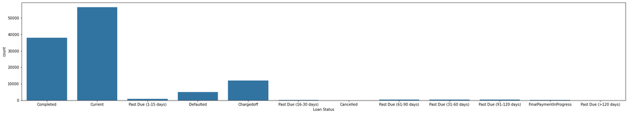

```python
# a standard-scaled plot

plt.figure(figsize=[30, 5])
default_color = sb.color_palette()[0]
sb.countplot(data = df, x = 'LoanStatus', color = default_color)
plt.xlabel('Loan Status')
plt.show()
```

Loan status has long tail distribution with most of loans being Current. LoanStatus is clearly unimodal with one peak at 'Current' status

Now let us look at other predictor variables of interest: Employment Status, Debt To Income Ratio, Property ownership, Income Range, Employment Status Duration,Stated Monthly Income, Borrower State, Available Bankcard Credit, Recommendations, Investors, and Occupation

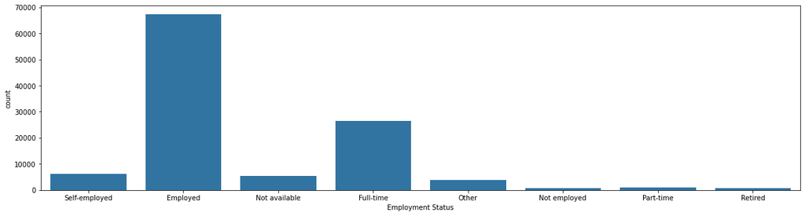

```python
#plot for employment status

plt.figure(figsize=[ 20, 5])
default_color = sb.color_palette()[0]
sb.countplot(data = df, x = 'EmploymentStatus', color = default_color)
plt.xlabel('Employment Status')
plt.show()
```

From the visualization, Most loans are from the employed individuals but followed by full-time. This make sense as it can ensure monthly cashflow we can predict these two have high chance to pay the loans but impossible to conclude now

```python
#checking maximum value for Debt To Income Ratio so to understand number of bins
df['DebtToIncomeRatio'].max()
```

```
10.01
```

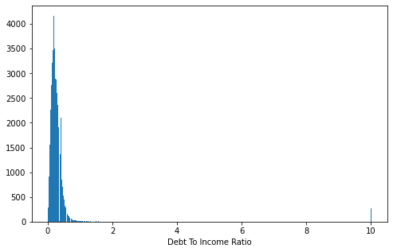

```python
#plot for distribution of Debt To Income Ratio

binsize = 0.01
bins = np.arange(0, df['DebtToIncomeRatio'].max()+binsize, binsize)

plt.figure(figsize=[8, 5])
plt.hist(data = df, x = 'DebtToIncomeRatio', bins = bins)
plt.xlabel('Debt To Income Ratio')
plt.show()
```

Most loans have debt to income ratio ranging from 0 to 2, which is ideal for the financial institution to put this ratio as low as possible. Creating high chance of repays. Low debt to income ratio shows the individual had considerable income compared to the loan requested

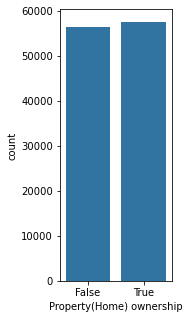

```python
#plot for distribution of Property ownership

plt.figure(figsize=[ 2, 5])
default_color = sb.color_palette()[0]
sb.countplot(data = df, x = 'IsBorrowerHomeowner', color = default_color)
plt.xlabel('Property(Home) ownership')
plt.show()
```

Most of loans are from individuals with property ownership. But we can see there is small difference between two.

Property ownership can be added as one of the factor that will ensure the financial institution to get back their loans as they can act as collateral

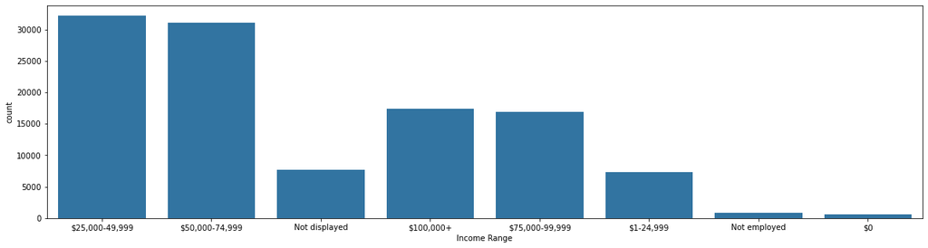

```python
#plot for distribution of IncomeRange

plt.figure(figsize=[ 20, 5])
default_color = sb.color_palette()[0]
sb.countplot(data = df, x = 'IncomeRange', color = default_color)
plt.xlabel('Income Range')
plt.show()
```

Income range of USD25,000 to 49,999 recorded by most of loan takers.There can be assurance of cashflow from this trend which is followed by group of USD50,000-74,999. Also some of USD75000 to 99,999 and more than USD100,000 have a considerable same number

```python
#checking maximum value for Employment Status Duration so to understand number of bins
df['EmploymentStatusDuration'].max()
```

```
755.0
```

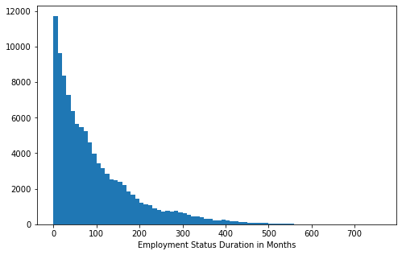

```python
#plot for distribution of Employment Status Duration

binsize = 10
bins = np.arange(0, df['EmploymentStatusDuration'].max()+binsize, binsize)

plt.figure(figsize=[8, 5])
plt.hist(data = df, x = 'EmploymentStatusDuration', bins = bins)
plt.xlabel('Employment Status Duration in Months')
plt.show()
```

```python
#checking maximum value for Stated Monthly Income so to understand number of bins
df['StatedMonthlyIncome'].max()
```

```
1750002.916667
```

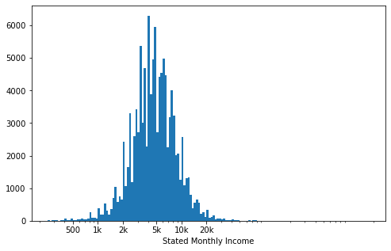

```python
#plot for distribution of Stated Monthly Income
log_binsize = 0.025
bins = 10 ** np.arange(2.4, np.log10(df['StatedMonthlyIncome'].max())+log_binsize, log_binsize)

plt.figure(figsize=[8, 5])
plt.hist(data = df, x = 'StatedMonthlyIncome', bins = bins)
plt.xscale('log')
plt.xticks([500, 1e3, 2e3, 5e3, 1e4, 2e4], [500, '1k', '2k', '5k', '10k', '20k'])
plt.xlabel('Stated Monthly Income')
plt.show()
```

The distribution of stated monthly salary is Unimodal with peak between USD2,000 and USD10,000 also slightly left skewed

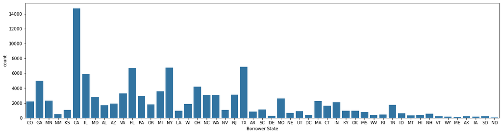

```python
#plot for distribution of borrower state

plt.figure(figsize=[ 20, 5])
default_color = sb.color_palette()[0]
sb.countplot(data = df, x = 'BorrowerState', color = default_color)
plt.xlabel('Borrower State')
plt.show()
```

The distribution is unimodal with the peak at California. We have most of loans from people living at California. Interesting, we this can suggest high cashflow in California. Other loans come from Texas, Newyork and Florida, busy places

```python
#checking maximum value for Available Bankcard Credit so to understand number of bins
df['AvailableBankcardCredit'].max()
```

```
646285.0
```

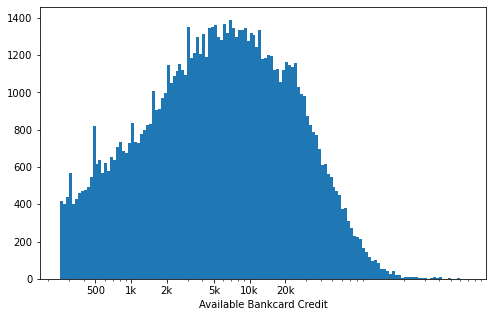

```python
#plot for distribution of Available Bankcard Credit

log_binsize = 0.025
bins = 10 ** np.arange(2.4, np.log10(df['AvailableBankcardCredit'].max())+log_binsize, log_binsize)

plt.figure(figsize=[8, 5])
plt.hist(data = df, x = 'AvailableBankcardCredit', bins = bins)
plt.xscale('log')
plt.xticks([500, 1e3, 2e3, 5e3, 1e4, 2e4], [500, '1k', '2k', '5k', '10k', '20k'])
plt.xlabel('Available Bankcard Credit')
plt.show()
```

The distribution have flat top ranging from USD2,000 to USD20,000 and slightly right skewed. There is high accumulation of loans where by individuals have bank card credits USD2,000-20,000

```python
#checking maximum value for Recommendations so to understand number of bins
df['Recommendations'].max()
```

```
39
```

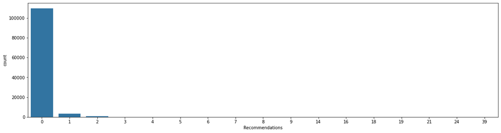

```python
#plot for distribution of Recommendations

plt.figure(figsize=[ 20, 5])
default_color = sb.color_palette()[0]
sb.countplot(data = df, x = 'Recommendations', color = default_color)
plt.xlabel('Recommendations')
plt.show()
```

Interms of recommendations most of loans have no recommendation it’s not a crucial thing but it can add credit whether the loan can be repaid or not

```python
#checking maximum value for Investors  so to understand number of bins
df['Investors'].max()
```

```
1189
```

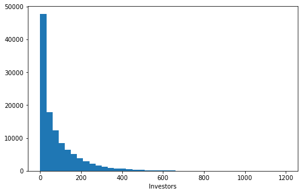

```python
#plot for distribution of Investors
binsize=30
bins = np.arange(0, df['Investors'].max()+binsize, binsize)

plt.figure(figsize=[8, 5])
plt.hist(data = df, x = 'Investors', bins = bins)
plt.xlabel('Investors')
plt.show()
```

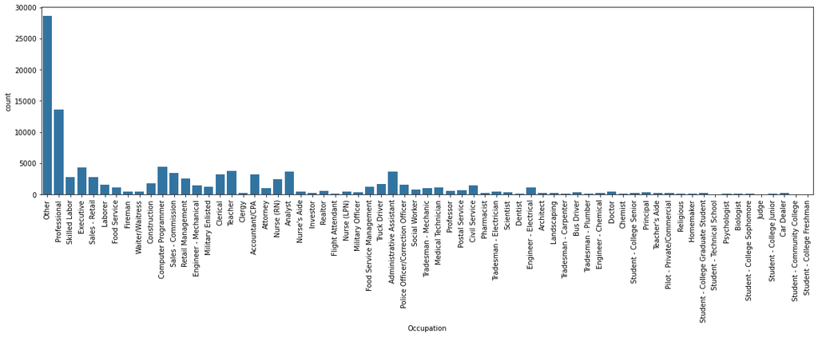

```python
#plot for distribution of Occupation
plt.figure(figsize=[ 20, 5])
default_color = sb.color_palette()[0]
sb.countplot(data = df, x = 'Occupation', color = default_color)
plt.xticks(rotation=90)
plt.xlabel('Occupation')
plt.show()
```

The distribution is unimodal with the peak at “others” followed by professionals. The distribution is also left skewed

### Discuss the distribution(s) of your variable(s) of interest. Were there any unusual points? Did you need to perform any transformations?

The Stated Monthly Income variable took on a large range of values, so I looked at the data using a log transform. Under the transformation, the data looked unimodal, with one peak between USD2,000 and USD10,000.

### Of the features you investigated, were there any unusual distributions? Did you perform any operations on the data to tidy, adjust, or change the form of the data? If so, why did you do this?

Also the variable Available Bankcard Credit took on a large range of values, so I looked at the data using a log transform, the data have flat top ranging from USD2,000 to USD20,000 and slightly right skewed

## Bivariate Exploration

Let us check the pairwise correlations present between features in the data.

```python
numeric_var = ['DebtToIncomeRatio', 'EmploymentStatusDuration', 'StatedMonthlyIncome', 'AvailableBankcardCredit', 'Recommendations', 'Investors']
categorical_var = ['LoanStatus', 'EmploymentStatus', 'IsBorrowerHomeowner', 'IncomeRange', 'BorrowerState', 'Occupation']
```

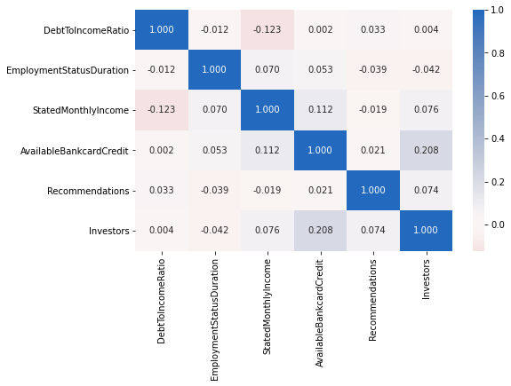

```python
# correlation plot
plt.figure(figsize = [8, 5])
sb.heatmap(df[numeric_var].corr(), annot = True, fmt = '.3f',
           cmap = 'vlag_r', center = 0)
plt.show()
```

Few features correlate to each other here but what to take into consideration is available bank credit with stated monthly income

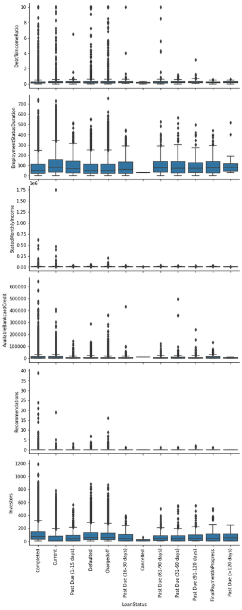

```python
def boxgrid(x, y, **kwargs):
    """ Quick hack for creating box plots with seaborn's PairGrid. """
    default_color = sb.color_palette()[0]
    sb.boxplot(x, y, color = default_color)

plt.figure(figsize = [10, 10])
g = sb.PairGrid(data = df, y_vars = numeric_var, x_vars = ['LoanStatus'],
                size = 3, aspect = 2.5)
g.map(boxgrid)
plt.xticks(rotation=90)
plt.show();
```

There is some negative relationships for the features like debt to income ratio and Recommendations. When the value of these features increases the number of completed loans and current loans tend to decrease these features are worthwhile exploring before reaching the final conclusion for the financial institution

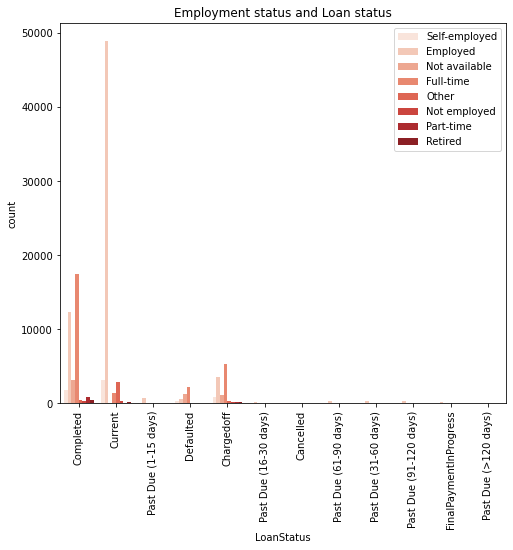

```python
#loan status vs employment status
plt.figure(figsize = [8, 7])

sb.countplot(data = df, x = 'LoanStatus', hue = 'EmploymentStatus', palette = 'Reds')
plt.legend(loc='upper right')
plt.xticks(rotation=90)
plt.title('Employment status and Loan status')
plt.show()
```

For employment status employed and full-time showed high trend for completed and current loans the trend decrease as you approach not employed and loans from retired individuals

[output not shown]

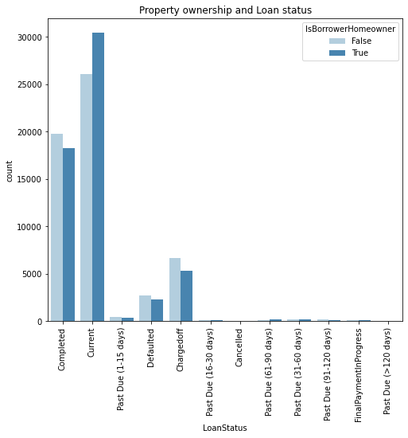

```python
#loan status vs property ownership
plt.figure(figsize = [8, 7])
sb.countplot(data = df, x = 'LoanStatus', hue = 'IsBorrowerHomeowner', palette = 'Blues')
plt.xticks(rotation=90)
plt.title('Property ownership and Loan status')
plt.show
```

Guess what? For the property Ownership Trend went so different from our perspective loans that are not home owners had a lot of completed loans. But for the current loans home owners beat the number

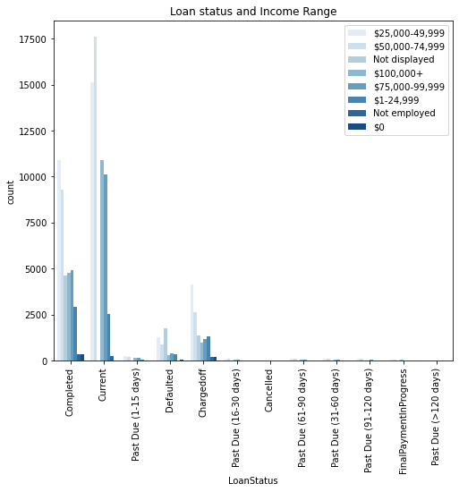

```python
#loan status and Income Range
plt.figure(figsize = [8, 7])
sb.countplot(data = df, x = 'LoanStatus', hue = 'IncomeRange', palette = 'Blues')
plt.xticks(rotation=90)
plt.legend(loc='upper right')
plt.title('Loan status and Income Range')
plt.show()
```

For most loans that are completed or current income range of USD25,000-49,999 and USD50,000 - 74,999 has the most number of loans the trend decrease as you approach to unemployed

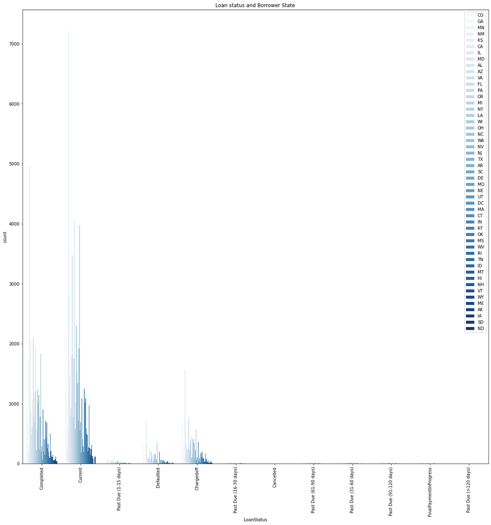

```python
#loan status and Borrower State
plt.figure(figsize = [20, 20])
sb.countplot(data = df, x = 'LoanStatus', hue = 'BorrowerState', palette = 'Blues')
plt.xticks(rotation=90)
plt.legend(loc='upper right')
plt.title('Loan status and Borrower State')
plt.show()
```

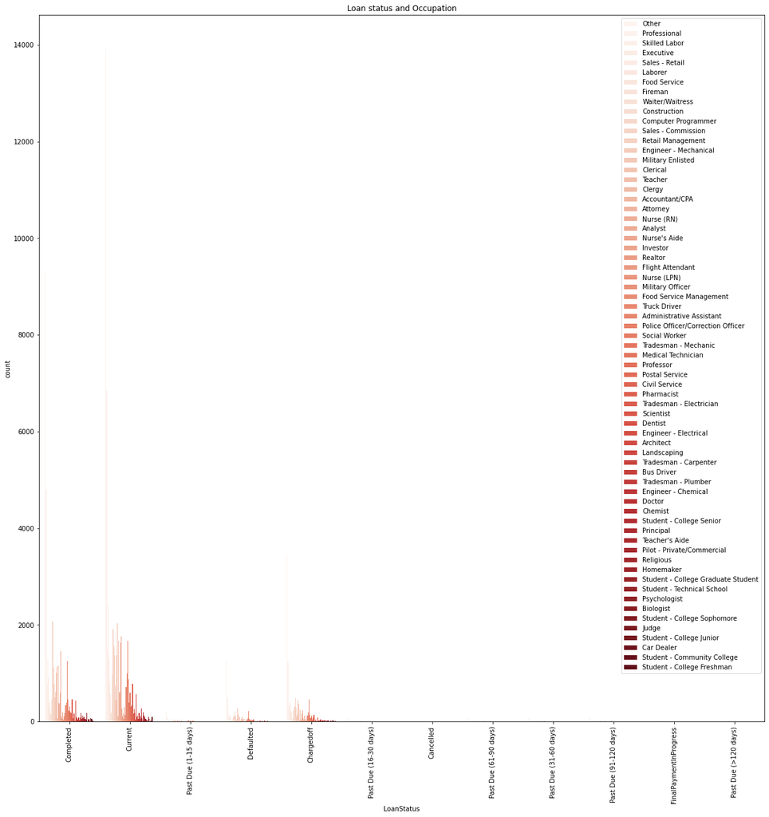

```python
#loan status and occupation
plt.figure(figsize = [20, 20])
sb.countplot(data = df, x = 'LoanStatus', hue = 'Occupation', palette = 'Reds')
plt.xticks(rotation=90)
plt.legend(loc='upper right')
plt.title('Loan status and Occupation')
plt.show()
```

Trend shows completed and current loans are from professionals, skilled labor and executives. The trend decrease as you approach to student-College Freshman

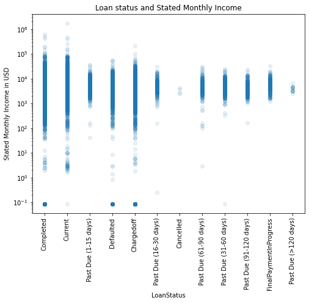

```python
#Scatter plot of loan status and Stated Monthly Income
plt.figure(figsize = [8, 6])
plt.scatter(data = df, x = 'LoanStatus', y = 'StatedMonthlyIncome', alpha = 1/10)
plt.yscale('log')
plt.ylabel('Stated Monthly Income in USD')
plt.xticks(rotation=90)
plt.xlabel('LoanStatus')
plt.title('Loan status and Stated Monthly Income')
plt.show()
```

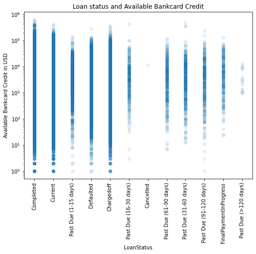

```python
#Scatter plot of loan status and Available Bankcard Credit
plt.figure(figsize = [8, 6])
plt.scatter(data = df, x = 'LoanStatus', y = 'AvailableBankcardCredit', alpha = 1/10)
plt.yscale('log')
plt.ylabel('Available Bankcard Credit in USD')
plt.xticks(rotation=90)
plt.xlabel('LoanStatus')
plt.title('Loan status and Available Bankcard Credit')
plt.show()
```

### Did you observe any interesting relationships between the other features (not the main feature(s) of interest)?

We expected property ownership to be one of the key features for loans completion as most of financial institutions use houses and other properties as collaterals to offer access to loans. But data shows people with no houses are the one who completed there loans at high number compared to those with property ownership

This suppose to be taken to much of consideration. Financial institutions must modify there rules and procedures to make sure those with considerable cashflow are prioritized

## Multivariate Exploration

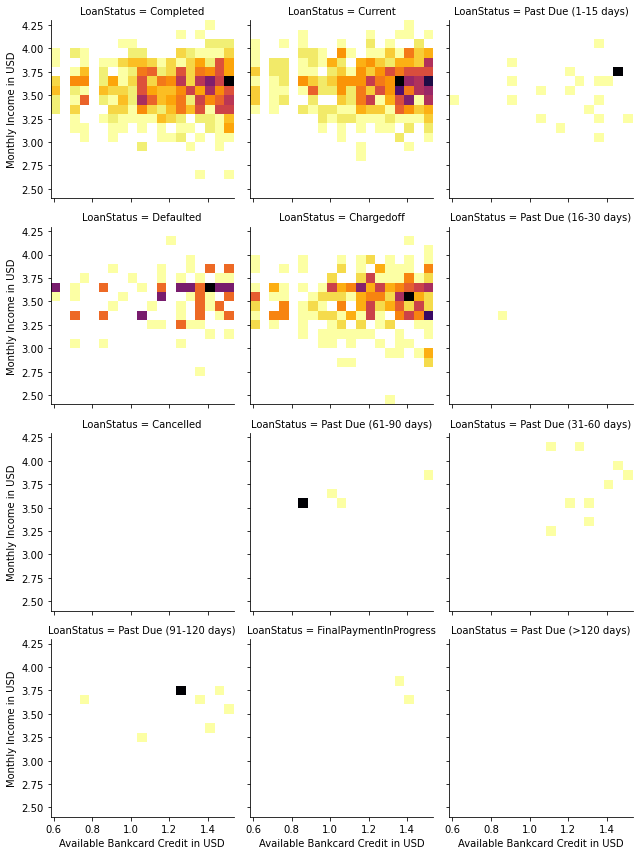

```python
# create faceted heat maps on each variable of loan status under stated monthly income and available bank card credity
g = sb.FacetGrid(data = df, col = 'LoanStatus', col_wrap = 3)

def cuberoot_trans(x, inverse = False):
    """ quick function for computing cube root and cube operations """
    if not inverse:
        return x ** (1/3)
    else:
        return x ** 3

def hist2dgrid(x, y, **kwargs):
    """ Quick hack for creating heat maps with seaborn's PairGrid. """
    palette = kwargs.pop('color')
    bins_x = np.arange(cuberoot_trans(.2), cuberoot_trans(3.5)+.05, .05)
    bins_y = np.arange(2.4, 4.3+0.1, 0.1)
    plt.hist2d(x, y, bins = [bins_x, bins_y], cmap = palette, cmin = 0.5)


def log_trans(x, inverse = False):
    """ quick function for computing log and power operations """
    if not inverse:
        return np.log10(x)
    else:
        return np.power(10, x)
df['log_BankcardCredit'] = df['AvailableBankcardCredit'].apply(log_trans)
df['log_MonthlyIncome'] = df['StatedMonthlyIncome'].apply(log_trans)

g.map(hist2dgrid, 'log_BankcardCredit', 'log_MonthlyIncome', color = 'inferno_r')
g.set_xlabels('Available Bankcard Credit in USD')
g.set_ylabels('Monthly Income in USD')
plt.show()
```

[figure not shown]

```python
#Stated Monthly Income, loan status and Borrower State
df_heatmap = df.pivot_table(values='log_MonthlyIncome', index='LoanStatus', columns='BorrowerState')
sb.heatmap(df_heatmap, annot=False)

plt.show()
```

[figure not shown]

```python
#Stated Monthly Income, loan status and Occupation
df_heatmap = df.pivot_table(values='log_MonthlyIncome', index='LoanStatus', columns='Occupation')
sb.heatmap(df_heatmap, annot=False)
plt.title('Heatmap of Stated Monthly Income, loan status and Occupation')
plt.show()
```

For loans with Stated Monthly Income different occupations had different chance to pay the loans. The most important feature here is Stated Monthly Income which ensure cashflow

[figure not shown]

```python
#Stated Monthly Income, loan status and Income Range
df_heatmap = df.pivot_table(values='log_MonthlyIncome', index='LoanStatus', columns='IncomeRange')
sb.heatmap(df_heatmap, annot=False)
plt.title('Heatmap of Stated Monthly Income, loan status and Income Range')
plt.show()
```

For loans with Stated Monthly Income all income range except those unemployed, and not displayed have equal chance to repay the loans, interesting! More can be explored here

[figure not shown]

```python
#available bank credit, loan status and Income Range
df_heatmap = df.pivot_table(values='log_BankcardCredit', index='LoanStatus', columns='IncomeRange')
sb.heatmap(df_heatmap, annot=False)
plt.title('Heatmap of Available bank credit, loan status and Income Range')
plt.show()
```

[figure not shown]

```python
#available bank credit, loan status and Occupation
df_heatmap = df.pivot_table(values='log_BankcardCredit', index='LoanStatus', columns='Occupation')
sb.heatmap(df_heatmap, annot=False)
plt.title('Heatmap of Available bank credit, loan status and Occupation')
plt.show()
```

[figure not shown]

```python
#available bank credit, loan status and borrower state
df_heatmap = df.pivot_table(values='log_BankcardCredit', index='LoanStatus', columns='BorrowerState')
sb.heatmap(df_heatmap, annot=False)
plt.title('Heatmap of Available bank credit, loan status and borrower state')
plt.show()
```

Heatmap show most people with available bank credit have their loans not payed yet regardless of their location

## Conclusions

Cashflow is essential feature to consider that can guarantee the payment of the loan. Features like stated monthly income, availability bank card credit and income range are the most important to consider. Regardless of places where the borrowers came from as long as there is assured cashflow a loan has high chance to be repaid